# Homework 6 alternate solutions

Dr. Dasgupta

2019-10-23

First we read the data into a list. Why? because we know we’re going to process all the datasets the same way, and we can use functional programming and loops to do it all efficiently without copy-pasting.

```r
dirname <- 'data'
#dir_ls(dirname, glob='*.csv')

sites <- c('Brain','Colon','Esophagus','Lung','Oral')
fnames <- paste0(sites, '.csv')

dat1 <- rio::import_list(path(dirname, fnames)) %>%
  map(janitor::clean_names)
```

What is `map` doing? It is applying the same function, here `janitor::clean_names`, to each element of the list, which is a list of data.frames. Similarly

```r
dat1_both <- map(dat1, select, year_of_diagnosis, ends_with("both_sexes"))
dat1_male <- map(dat1, select, year_of_diagnosis, ends_with('_males'))
dat1_female <- map(dat1, ~select(., year_of_diagnosis, ends_with('females')))
```

This creates lists of datasets, just for both sexes, males and females, where each element of the list comes from each site

We want to do some re-naming, so that when we merge the datasets, we have unique column names. This is harder to do using `map`, so we use a `for`-loop, instead.

```r
for(i in 1:length(dat1_both)){ # Note all the lists are the same size, so this works
  dat1_both[[i]] <- dat1_both[[i]] %>% set_names(str_replace(names(dat1_both[[i]]),
                                                             'both_sexes',
                                                             names(dat1_both)[i]))
  dat1_male[[i]] <- dat1_male[[i]] %>% set_names(str_replace(names(dat1_male[[i]]),
                                                             'males',
                                                             names(dat1_male)[i]))
  dat1_female[[i]] <- dat1_female[[i]] %>% set_names(str_replace(names(dat1_female[[i]]),
                                                             'females',
                                                             names(dat1_female)[i]))

}
```

Now we can join them. In the homework, you did this sequentially. However there are programming tricks that make this much easier. The function `Reduce` is one such. It repeatedly applies a function with two arguments successively to elements of a list.

```r
dat2_both <- Reduce(left_join, dat1_both)
dat2_male <- Reduce(left_join, dat1_male)
dat2_female <- Reduce(left_join, dat1_female)
```

We then re-form a list of datasets, since we will be doing some common processing again

```r
dat2 <- list('both' = dat2_both, 'male' = dat2_male, 'female'=dat2_female)
for(i in 1:length(dat2)){
  names(dat2[[i]]) <- str_replace(names(dat2[[i]]), 'all_races','allraces')
  dat2[[i]] <- mutate_at(dat2[[i]], vars(-year_of_diagnosis), as.numeric)
}
dat3 <- map(dat2, function(d) d %>%
              slice(-1) %>%
              gather(variable, rate, -year_of_diagnosis) %>%
              separate(variable, c('race','site'), sep='_', extra='merge') %>%
              mutate(year_of_diagnosis = as.numeric(year_of_diagnosis)))
```

Now it turns out that you can do the graphs in a loop, to create all the graphs in one go. This method will suffice if you annotate the graphs properly.

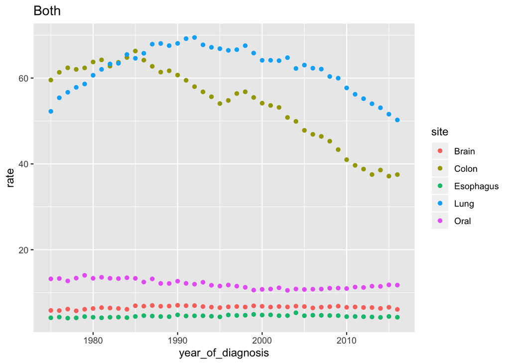

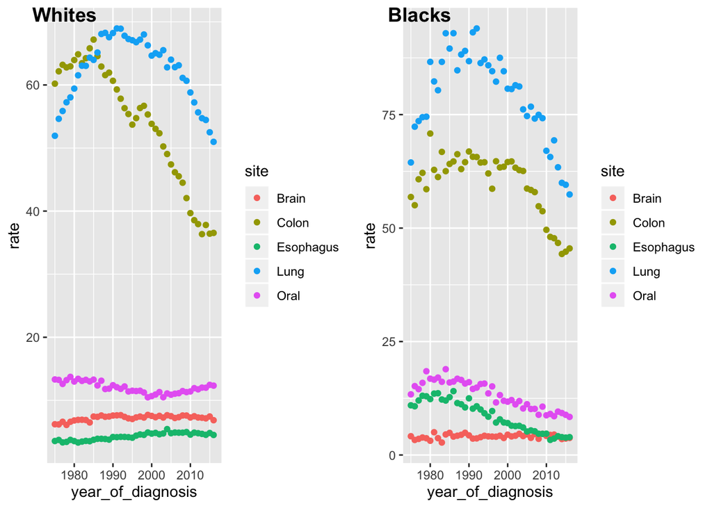

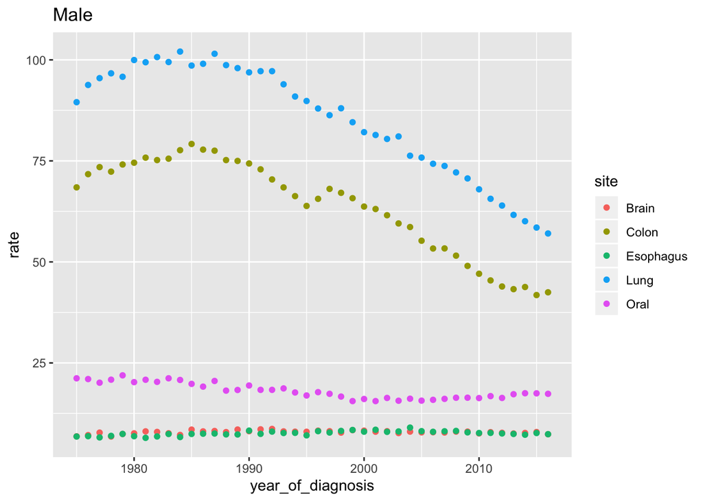

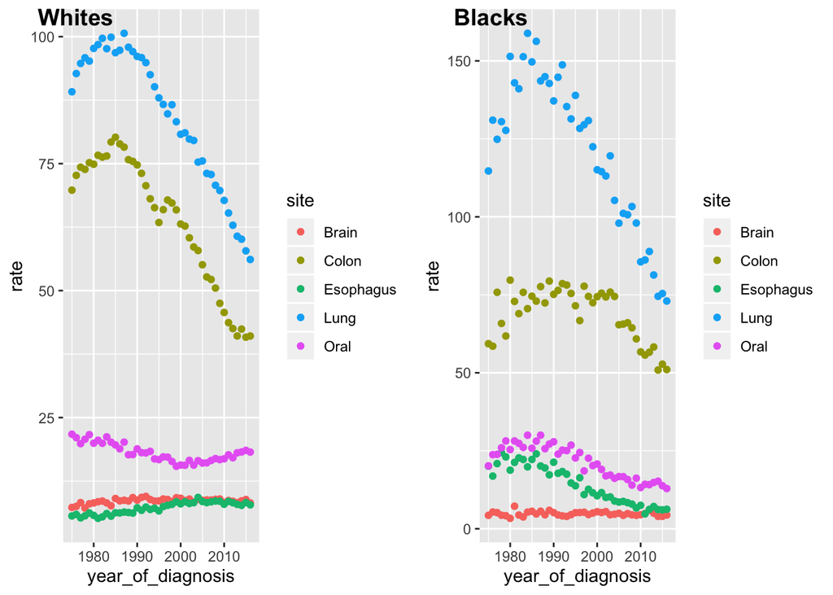

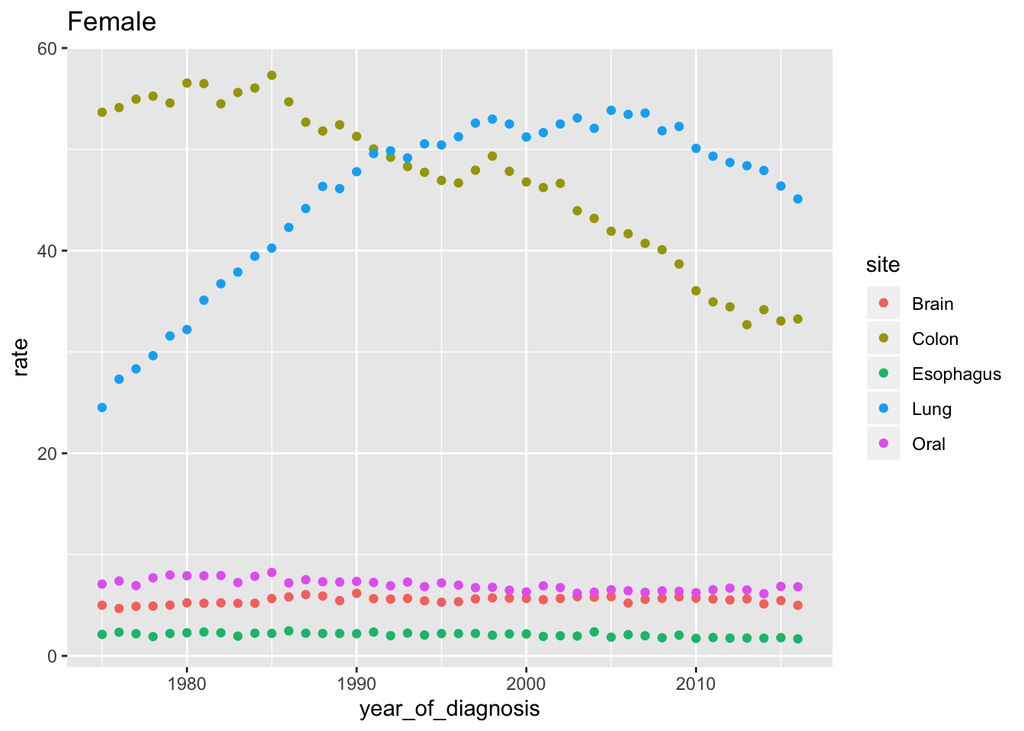

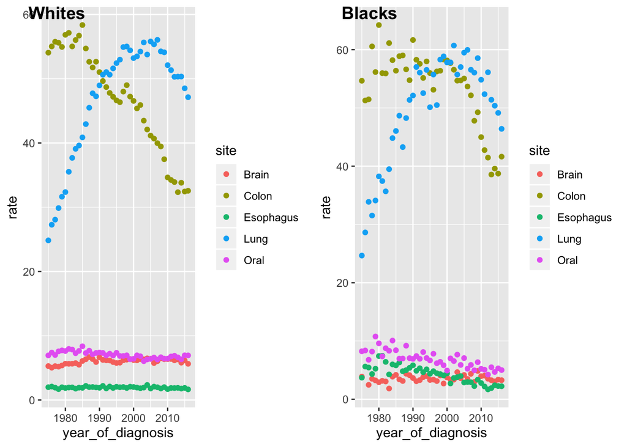

```r
for(i in 1:length(dat3)){
  print(ggplot(dat3[[i]] %>% filter(race=='allraces'),
         aes(x = year_of_diagnosis, y = rate, color=site)) +
    geom_point() +
      labs(title = str_to_title(names(dat3)[i])))
  plt1 <- ggplot(dat3[[i]] %>% filter(race=='whites'),
                 aes(x = year_of_diagnosis, y = rate, color=site)) +
    geom_point() +
    labs(main = str_to_title(names(dat3)[i]))
  plt2 <- ggplot(dat3[[i]] %>% filter(race=='blacks'),
                 aes(x = year_of_diagnosis, y = rate, color=site)) +
    geom_point()
  print(cowplot::plot_grid(plt1, plt2, nrow=1, labels = c('Whites','Blacks')) )
}
```